# Analysis of NYC 311 Service Requests

This is an analysis of service requests in New York City dating back from 2010 to March of this year. The data can be found at: https://nycopendata.socrata.com/Social-Services/311-Service-Requests-from-2010-to-Present/erm2-nwe9

With the size of the data being around 10.7 GB and my machine being a Macbook Air in its last days - utilizing the cloud to compute was my only option. I first downloaded the file into my AWS S3 storage and then opened up an EC2 instance to compute.

```python
import pandas as pd
import boto3
import io
```

```python
client = boto3.client('s3') #low-level functional API
resource = boto3.resource('s3') #high-level object-oriented API
my_bucket = resource.Bucket('interview-stuff') #subsitute this for your s3 bucket name.
```

```python
obj = client.get_object(Bucket='interview-stuff', Key='311_service_requests.csv')
```

```python
df = pd.read_csv(io.BytesIO(obj['Body'].read()), dtype={'Incident Zip': 'str'})
```

# Question: What are the top features that affect the time to resolve a complaint? Do they change over time?

## Initial Processing

First step was to the initial wrangling done in Pandas. Initial impressions from the data show that there are a lot of columns displaying sparsity and redudancy. I initally set a minimum threshold of non-null values that a column could have for it to be dropped.

## Feature Selection

With not many of the features remaining contributing useful information - I wanted to observe four main factors that could affect the time to resolve a complaint: Agency, type of complaint, location, and the time. The four columns in this dataset that were used: Agency Name, Complaint Type, Incident Zip, and Borough. I also extracted the month and year from the date created column.

## Feature Processing

3 of the four features chosen exhibited high cardinality:

```python
df.head()
```

|  | Unique Key | Created Date | Closed Date | Agency | Agency Name | Complaint Type | Descriptor | Location Type | Incident Zip | Incident Address | ... | Bridge Highway Name | Bridge Highway Direction | Road Ramp | Bridge Highway Segment | Garage Lot Name | Ferry Direction | Ferry Terminal Name | Latitude | Longitude | Location |
| --- | --- | --- | --- | --- | --- | --- | --- | --- | --- | --- | --- | --- | --- | --- | --- | --- | --- | --- | --- | --- | --- |
| 0 | 26435528 | 10/04/2013 08:32:00 AM | 10/04/2013 08:37:00 AM | DEP | Department of Environmental Protection | Water System | Dirty Water (WE) | NaN | 10022 | 325 EAST 54 STREET | ... | NaN | NaN | NaN | NaN | NaN | NaN | NaN | 40.757069 | -73.965933 | (40.75706852462872, -73.96593314322774) |
| 1 | 26435529 | 10/04/2013 12:21:00 PM | 10/04/2013 12:23:00 PM | DEP | Department of Environmental Protection | Water System | Dirty Water (WE) | NaN | 10022 | 250 EAST 54 STREET | ... | NaN | NaN | NaN | NaN | NaN | NaN | NaN | 40.757835 | -73.967792 | (40.757834843087686, -73.96779168686822) |
| 2 | 26435531 | 10/04/2013 12:22:00 PM | 10/04/2013 06:00:00 PM | DEP | Department of Environmental Protection | Water System | Dirty Water (WE) | NaN | 11235 | 2461 EAST 13 STREET | ... | NaN | NaN | NaN | NaN | NaN | NaN | NaN | 40.590727 | -73.956747 | (40.59072661066776, -73.95674658536144) |
| 3 | 26435532 | 10/04/2013 12:28:00 PM | 10/05/2013 11:52:00 AM | DEP | Department of Environmental Protection | Asbestos | Asbestos Complaint (B1) | NaN | 11378 | 70-02 54 AVENUE | ... | NaN | NaN | NaN | NaN | NaN | NaN | NaN | 40.729215 | -73.893624 | (40.729214615878035, -73.89362433399548) |
| 4 | 26435533 | 10/04/2013 08:45:00 AM | 10/04/2013 08:50:00 AM | DEP | Department of Environmental Protection | Water System | Dirty Water (WE) | NaN | 10022 | 214 EAST 51 STREET | ... | NaN | NaN | NaN | NaN | NaN | NaN | NaN | 40.756208 | -73.969760 | (40.7562077426825, -73.96975964862594) |

5 rows × 53 columns

```python
df.shape
```

```
(17312578, 53)
```

```python
df.info(null_counts=True)
```

```
<class 'pandas.core.frame.DataFrame'>
RangeIndex: 17312578 entries, 0 to 17312577
Data columns (total 53 columns):
Unique Key                        17312578 non-null int64
Created Date                      17312578 non-null object
Closed Date                       16728443 non-null object
Agency                            17312578 non-null object
Agency Name                       17312578 non-null object
Complaint Type                    17312578 non-null object
Descriptor                        17132890 non-null object
Location Type                     12852719 non-null object
Incident Zip                      16110560 non-null object
Incident Address                  13525995 non-null object
Street Name                       13524870 non-null object
Cross Street 1                    11816846 non-null object
Cross Street 2                    11748688 non-null object
Intersection Street 1             2666954 non-null object
Intersection Street 2             2662504 non-null object
Address Type                      16494949 non-null object
City                              16116236 non-null object
Landmark                          8738 non-null object
Facility Type                     4358989 non-null object
Status                            17312545 non-null object
Due Date                          7121293 non-null object
Resolution Description            16636310 non-null object
Resolution Action Updated Date    16951524 non-null object
Community Board                   17312578 non-null object
Borough                           17312578 non-null object
X Coordinate (State Plane)        15494078 non-null float64
Y Coordinate (State Plane)        15494078 non-null float64
Park Facility Name                17312578 non-null object
Park Borough                      17312578 non-null object
School Name                       17312578 non-null object
School Number                     17308811 non-null object
School Region                     17218991 non-null object
School Code                       17218994 non-null object
School Phone Number               17312578 non-null object
School Address                    17312569 non-null object
School City                       17312578 non-null object
School State                      17312578 non-null object
School Zip                        17312577 non-null object
School Not Found                  7025891 non-null object
School or Citywide Complaint      2354 non-null object
Vehicle Type                      7608 non-null object
Taxi Company Borough              15267 non-null object
Taxi Pick Up Location             129096 non-null object
Bridge Highway Name               45823 non-null object
Bridge Highway Direction          45760 non-null object
Road Ramp                         45364 non-null object
Bridge Highway Segment            57028 non-null object
Garage Lot Name                   5103 non-null object
Ferry Direction                   3988 non-null object
Ferry Terminal Name               14263 non-null object
Latitude                          15494078 non-null float64
Longitude                         15494078 non-null float64
Location                          15494078 non-null object
dtypes: float64(4), int64(1), object(48)
memory usage: 6.8+ GB
```

```python
df1 = df.dropna(axis=1, thresh=12852719)
df1.info(null_counts=True)
```

```
<class 'pandas.core.frame.DataFrame'>
RangeIndex: 17312578 entries, 0 to 17312577
Data columns (total 34 columns):
Unique Key                        17312578 non-null int64
Created Date                      17312578 non-null object
Closed Date                       16728443 non-null object
Agency                            17312578 non-null object
Agency Name                       17312578 non-null object
Complaint Type                    17312578 non-null object
Descriptor                        17132890 non-null object
Location Type                     12852719 non-null object
Incident Zip                      16110560 non-null object
Incident Address                  13525995 non-null object
Street Name                       13524870 non-null object
Address Type                      16494949 non-null object
City                              16116236 non-null object
Status                            17312545 non-null object
Resolution Description            16636310 non-null object
Resolution Action Updated Date    16951524 non-null object
Community Board                   17312578 non-null object
Borough                           17312578 non-null object
X Coordinate (State Plane)        15494078 non-null float64
Y Coordinate (State Plane)        15494078 non-null float64
Park Facility Name                17312578 non-null object
Park Borough                      17312578 non-null object
School Name                       17312578 non-null object
School Number                     17308811 non-null object
School Region                     17218991 non-null object
School Code                       17218994 non-null object
School Phone Number               17312578 non-null object
School Address                    17312569 non-null object
School City                       17312578 non-null object
School State                      17312578 non-null object
School Zip                        17312577 non-null object
Latitude                          15494078 non-null float64
Longitude                         15494078 non-null float64
Location                          15494078 non-null object
dtypes: float64(4), int64(1), object(29)
memory usage: 4.4+ GB
```

```python
columns = ['Unique Key', 'Created Date', 'Closed Date', 'Agency Name', 'Complaint Type', 'Borough', 'Incident Zip']

df2 = df1[columns]
```

```python
df2.head()
```

|  | Unique Key | Created Date | Closed Date | Agency Name | Complaint Type | Borough | Incident Zip |
| --- | --- | --- | --- | --- | --- | --- | --- |
| 0 | 26435528 | 10/04/2013 08:32:00 AM | 10/04/2013 08:37:00 AM | Department of Environmental Protection | Water System | MANHATTAN | 10022 |
| 1 | 26435529 | 10/04/2013 12:21:00 PM | 10/04/2013 12:23:00 PM | Department of Environmental Protection | Water System | MANHATTAN | 10022 |
| 2 | 26435531 | 10/04/2013 12:22:00 PM | 10/04/2013 06:00:00 PM | Department of Environmental Protection | Water System | BROOKLYN | 11235 |
| 3 | 26435532 | 10/04/2013 12:28:00 PM | 10/05/2013 11:52:00 AM | Department of Environmental Protection | Asbestos | QUEENS | 11378 |
| 4 | 26435533 | 10/04/2013 08:45:00 AM | 10/04/2013 08:50:00 AM | Department of Environmental Protection | Water System | MANHATTAN | 10022 |

```python
df2.info()
```

[output not shown]

```python
df2['Agency Name'].value_counts()
```

```
Department of Housing Preservation and Development                          5033139
New York City Police Department                                             3793714
Department of Transportation                                                2375751
Department of Environmental Protection                                      1396446
Department of Parks and Recreation                                           762024
Department of Buildings                                                      716943
Department of Health and Mental Hygiene                                      440655
Department of Sanitation                                                     223055
Department of Finance                                                        203059
Taxi and Limousine Commission                                                193082
Department of Consumer Affairs                                               169051
BCC - Brooklyn South                                                         124984
HRA Benefit Card Replacement                                                  99612
BCC - Brooklyn North                                                          97407
A - Brooklyn                                                                  87293
Senior Citizen Rent Increase Exemption Unit                                   81091
Correspondence Unit                                                           80899
Operations Unit - Department of Homeless Services                             80484
BCC - Queens East                                                             79715
Department for the Aging                                                      79201
Refunds and Adjustments                                                       78653
BCC - Staten Island                                                           77149
A - Queens                                                                    76170
DHS Advantage Programs                                                        73021
BCC - Queens West                                                             52668
Property Exec Office                                                          47393
Personal Exemption Unit                                                       41346
BCC - Bronx                                                                   40687
A - Manhattan                                                                 36839
Queens East 12                                                                33815
                                                                             ...
School - Middle School for Academic and Social Excellence                         1
School - Community School for Social Justice                                      1
School - PS 198                                                                   1
School - Globe School for Environmental Research                                  1
School - PS 203 Oakland Gardens                                                   1
School - Kappa III                                                                1
School - Brooklyn Theatre Arts High School                                        1
School - Frederick Douglass Academy V Middle School                               1
School - Cypress Hills Collegiate Preparatory School                              1
School - The Anderson School                                                      1
School - Riverdale - Kingsbridge Academy (Middle School-High School 141)          1
School - Red Hook Neighborhood School                                             1
School - Millennium High School                                                   1
School - PS 134                                                                   1
School - MS 596 Peace Academy                                                     1
School - John V Lindsay Wildcat Academy Charter School                            1
School - Fanny High School for Fire and Life Safety                               1
School - University Neighborhood Middle School                                    1
School - New Voices School of Academic and Creative Arts                          1
School - Our World Neighborhood Charter School                                    1
School - Manhattan International High School                                      1
School - East Side Elementary School, PS 267                                      1
School - ALC Fundamentals Academy                                                 1
School - PS 260 Breuckelen                                                        1
School - Brooklyn Urban Garden Charter School                                     1
School - PS 199X The Shakespeare School                                           1
School - New Horizons School                                                      1
School - South Bronx Academy for Applied Media                                    1
School - Girls Preparatory Charter School of New York                             1
School - Citizens of the World Charter School 2                                   1
Name: Agency Name, Length: 1934, dtype: int64
```

```python
df2['Complaint Type'].value_counts()
```

```
Noise - Residential                  1396720
HEATING                               887869
HEAT/HOT WATER                        883327
Street Condition                      798271
Street Light Condition                785409
Blocked Driveway                      670300
PLUMBING                              632254
Illegal Parking                       580791
Water System                          526614
GENERAL CONSTRUCTION                  500863
Noise                                 372338
Traffic Signal Condition              363236
PAINT - PLASTER                       361258
UNSANITARY CONDITION                  318179
Noise - Street/Sidewalk               305422
Sewer                                 299812
Dirty Conditions                      283323
Noise - Commercial                    271953
ELECTRIC                              267117
PAINT/PLASTER                         262909
NONCONST                              260890
General Construction/Plumbing         244214
Sanitation Condition                  241778
Damaged Tree                          231754
Building/Use                          222058
Rodent                                212397
DOF Literature Request                203715
Missed Collection (All Materials)     184681
Broken Muni Meter                     172119
Derelict Vehicle                      156660
                                      ...
Employee Behavior                          4
General Question                           4
Hazardous Material                         4
DOHMH Literature Request                   4
Advocate - RPIE                            4
Advocate-Business Tax                      3
Laboratory                                 3
Comment                                    3
SNW                                        2
Killing/Trapping Pigeon                    2
Homebound Evacuation 4                     2
Trapping Pigeon                            2
Advocate - Levy                            1
Sewer Maintenance                          1
Sidewalk Cafe Heater                       1
Animal unsanitary condition                1
SG-99                                      1
Advocate - Lien                            1
LEAD                                       1
MOLD                                       1
CFC Recovery                               1
Unlicensed Dog                             1
Micro Switch                               1
Health and Safety                          1
Unspecified                                1
Biking/Rollerblading Off Path              1
Select Message Type...                     1
Meals Home Delivery Required               1
Asbestos/Garbage Nuisance                  1
CST                                        1
Name: Complaint Type, Length: 332, dtype: int64
```

```python
df2['Incident Zip'].value_counts()
```

```
11226         307486
10467         260438
11207         228171
10458         226165
10453         214216
10468         208822
11221         205562
10452         199605
11208         197020
10457         196320
11385         195258
10031         188592
10456         188072
11213         182290
11233         180615
```

[output cut: 47 more lines]

```python
df2['Borough'].value_counts()
```

```
BROOKLYN         4973147
QUEENS           3791173
MANHATTAN        3340906
BRONX            2997650
Unspecified      1386651
STATEN ISLAND     823051
Name: Borough, dtype: int64
```

```python
departments = ['Department of Housing Preservation and Development', 'New York City Police Department',
'Department of Transportation', 'Department of Environmental Protection','Department of Parks and Recreation',
'Department of Buildings', 'Department of Health and Mental Hygiene', 'Department of Sanitation','Department of Finance',
              'Taxi and Limousine Commission', 'Department of Consumer Affairs']
```

```python
df2 = df2.copy()
df2['Agency Name'] = df2['Agency Name'].apply(lambda x: x if x in departments else 'Other')
```

```python
df2['Agency Name'].value_counts()
```

```
Department of Housing Preservation and Development    5033139
New York City Police Department                       3793714
Department of Transportation                          2375751
Other                                                 2005659
Department of Environmental Protection                1396446
Department of Parks and Recreation                     762024
Department of Buildings                                716943
Department of Health and Mental Hygiene                440655
Department of Sanitation                               223055
Department of Finance                                  203059
Taxi and Limousine Commission                          193082
Department of Consumer Affairs                         169051
Name: Agency Name, dtype: int64
```

```python
# Create new complaint count column

df2['Complaint Count'] = df2.groupby('Complaint Type')['Complaint Type'].transform('count')
```

```python
# Create new zip code count column

df2['Zip Count'] = df2.groupby('Incident Zip')['Incident Zip'].transform('count')
df2['Zip Count'] = df2['Zip Count'].fillna(0).astype(int)
df2['Zip Count'] = df2['Zip Count'].astype(int)
```

```python
# Create target column - difference between date closed and date created

df2['Created Date'] = pd.to_datetime(df2['Created Date'], format="%m/%d/%Y %I:%M:%S %p")
df2['Closed Date'] = pd.to_datetime(df2['Closed Date'], errors='coerce', format="%m/%d/%Y %I:%M:%S %p")
df2 = df2[df2['Closed Date'].notnull()]
```

## Target Variable Exploratory Analysis

- Target variable: length in time between service request date created and date closed in days (Time Elapsed)
- I dropped all instances where the date closed was earler than the date created assuming that those instances were mistakes in data collection
- I then observed the distribution of the target column and began observing the feature-target relationship

```python
import numpy as np

df2['Time Elapsed'] = (df2['Closed Date'] - df2['Created Date'])
df2['Time Elapsed'] = df2['Time Elapsed'].astype('timedelta64[D]')
df2['Month'] = df2['Created Date'].dt.month
df2['Year'] = df2['Created Date'].dt.year
```

```python
errors = df2[df2['Created Date'] > df2['Closed Date']]
df2 = df2[~df2.index.isin(errors.index)]
```

```python
df2.head()
```

[output not shown]

```python
import seaborn as sb
import matplotlib.pyplot as plt
%matplotlib inline

plt.rcParams['figure.figsize'] = (18, 8)
```

## Target Variable Initial Thoughts

- As seen in the first histogram the target variable is sparse
- The first box plot taking a look at the time elapsed by month shows that there are some massive outliers ranging to 70000 days in between the date created and closed which also don't seem feasible
- To improve the distribution and remove the intense outliers I only looked at instances that had were dealt with within a year of the request creation

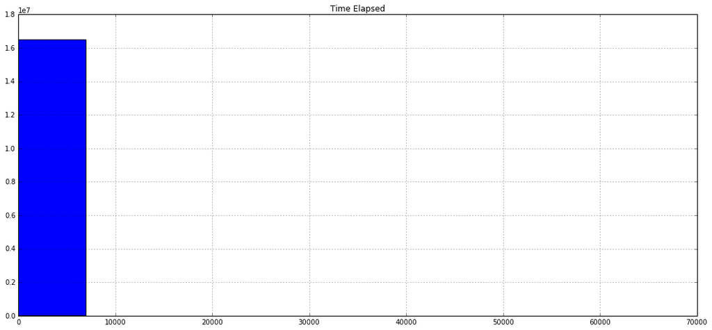

```python
df2['Time Elapsed'].hist()
plt.title('Time Elapsed')
plt.show()
```

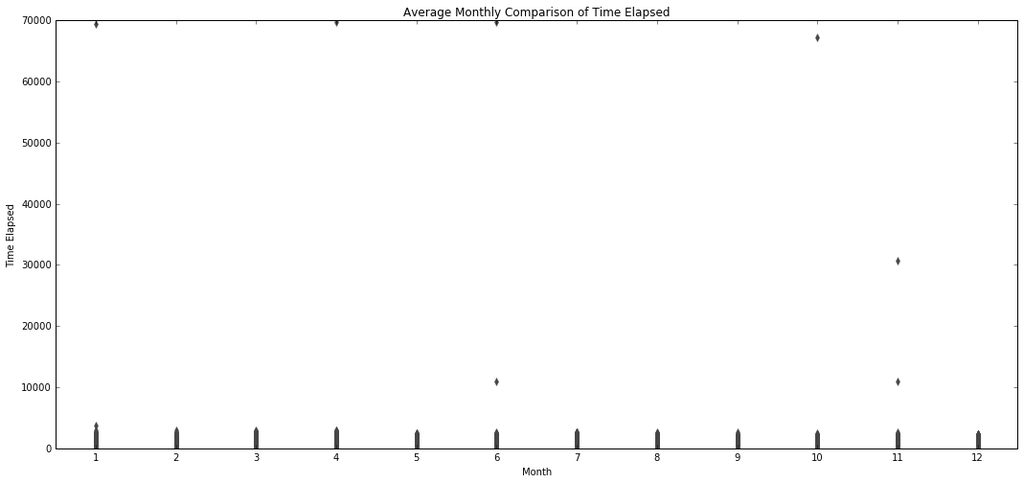

```python
sb.boxplot(x='Month', y='Time Elapsed', data=df2)
plt.title('Average Monthly Comparison of Time Elapsed')
plt.show()
```

## Further Target Variable Analysis

- After only including service requests dealt with within a year - the distribution is improved but still clearly sparse
- Looked at box plots at processed features that did not have high cardinality: month, year, agency, and borough
- Tough to see much of a difference between feature instances due to the sparsity of our target variable
- However for Agency Name the skew is not as bad for some and we can see distinguishable relationships

```python
# reduce to only within a year

df2 = df2[df2['Time Elapsed'] < 365]
```

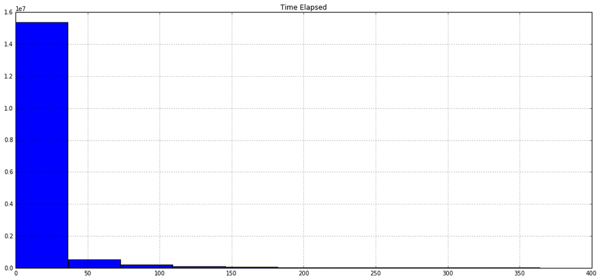

```python
df2['Time Elapsed'].hist()
plt.title('Time Elapsed')
plt.show()
```

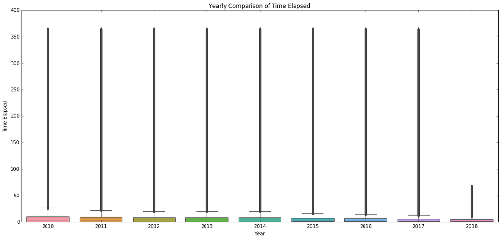

```python
sb.boxplot(x='Year', y='Time Elapsed', data=df2)
plt.title('Yearly Comparison of Time Elapsed')
plt.show()
```

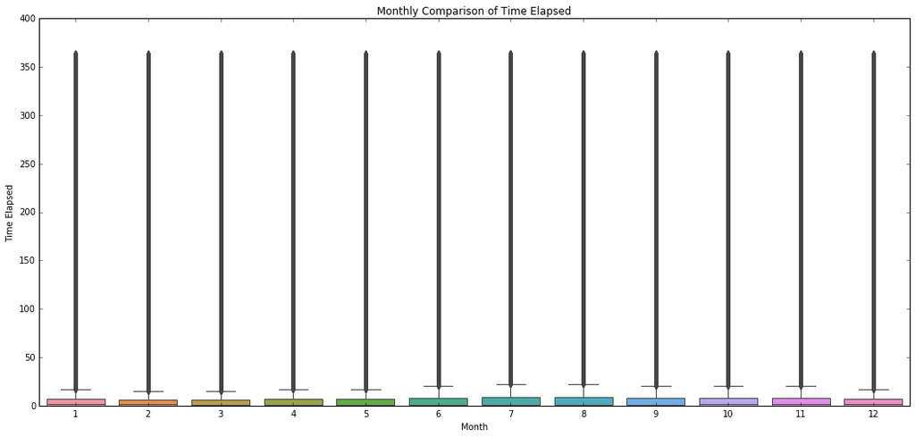

```python
sb.boxplot(x='Month', y='Time Elapsed', data=df2)
plt.title('Monthly Comparison of Time Elapsed')
plt.show()
```

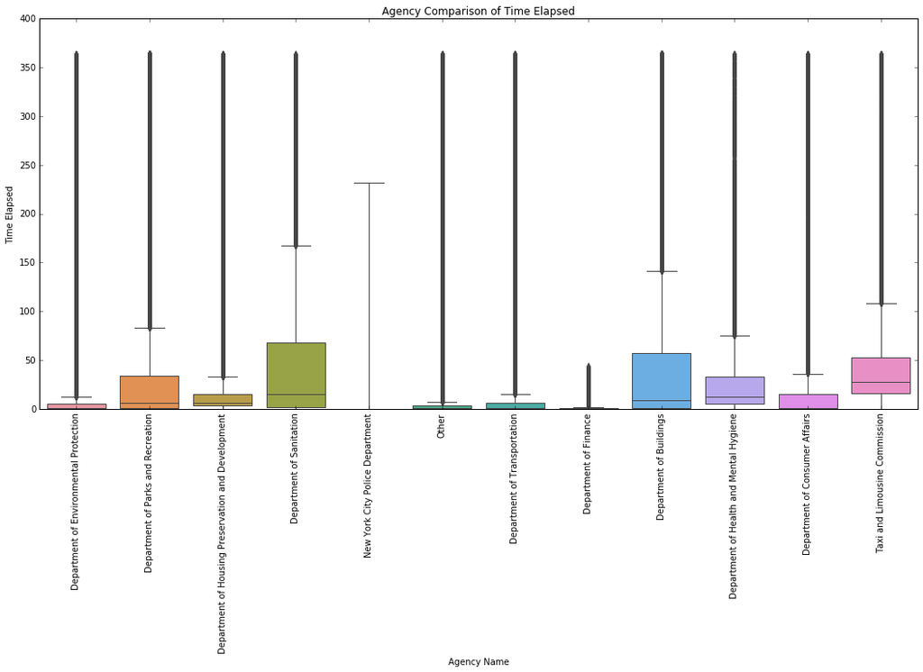

```python
# Department of Sanitation, Department of Buildings, Department of Health and Mental Hygiene

sb.boxplot(x='Agency Name', y='Time Elapsed', data=df2)
plt.title('Agency Comparison of Time Elapsed')
plt.xticks(rotation='vertical')
plt.show()
```

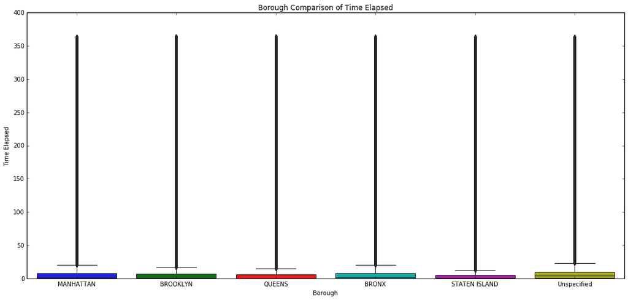

```python
sb.boxplot(x='Borough', y='Time Elapsed', data=df2)
plt.title('Borough Comparison of Time Elapsed')
plt.show()
```

# Modeling

- From the initial exploratory analysis there does not appear to be a linear relationship between the features and the target variable
- A non-linear model such as a decision tree seems to be a good idea due to the structure of the data as well as the desire for intrepretability
- Dummy variables for created for Borough and Agency Name since they aren't ordinal in nature

## Evaluation

- I chose to use the Root mean squared error to evaluate the model
- I tried an ensemble method after the decision tree to see how badly the first model was overfitting without incorporating cross validation
  - I chose a bagged random forest as opposed to a boosted model for simply computational purposes
- Used the feature importances attribute to observe the most important features

```python
df3 = df2[['Month', 'Year', 'Agency Name', 'Complaint Count', 'Borough', 'Zip Count']]
df3 = pd.get_dummies(df3)
df3['Time Elapsed'] = df2['Time Elapsed']
```

```python
df3.head()
```

|  | Month | Year | Complaint Count | Zip Count | Agency Name_Department of Buildings | Agency Name_Department of Consumer Affairs | Agency Name_Department of Environmental Protection | Agency Name_Department of Finance | Agency Name_Department of Health and Mental Hygiene | Agency Name_Department of Housing Preservation and Development | ... | Agency Name_New York City Police Department | Agency Name_Other | Agency Name_Taxi and Limousine Commission | Borough_BRONX | Borough_BROOKLYN | Borough_MANHATTAN | Borough_QUEENS | Borough_STATEN ISLAND | Borough_Unspecified | Time Elapsed |
| --- | --- | --- | --- | --- | --- | --- | --- | --- | --- | --- | --- | --- | --- | --- | --- | --- | --- | --- | --- | --- | --- |
| 0 | 10 | 2013 | 526614 | 67474 | 0 | 0 | 1 | 0 | 0 | 0 | ... | 0 | 0 | 0 | 0 | 0 | 1 | 0 | 0 | 0 | 0.0 |
| 1 | 10 | 2013 | 526614 | 67474 | 0 | 0 | 1 | 0 | 0 | 0 | ... | 0 | 0 | 0 | 0 | 0 | 1 | 0 | 0 | 0 | 0.0 |
| 2 | 10 | 2013 | 526614 | 149664 | 0 | 0 | 1 | 0 | 0 | 0 | ... | 0 | 0 | 0 | 0 | 1 | 0 | 0 | 0 | 0 | 0.0 |
| 3 | 10 | 2013 | 16315 | 77545 | 0 | 0 | 1 | 0 | 0 | 0 | ... | 0 | 0 | 0 | 0 | 0 | 0 | 1 | 0 | 0 | 0.0 |
| 4 | 10 | 2013 | 526614 | 67474 | 0 | 0 | 1 | 0 | 0 | 0 | ... | 0 | 0 | 0 | 0 | 0 | 1 | 0 | 0 | 0 | 0.0 |

5 rows × 23 columns

```python
len(df3)
```

```
16388939
```

```python
from sklearn import tree, ensemble, model_selection

features = [col for col in df3.columns if col != 'Time Elapsed']

X_train, X_test, y_train, y_test = model_selection.train_test_split(df3[features].values,
                                                                    df3["Time Elapsed"].values,
                                                                    test_size=0.3, random_state=42)
```

```python
from sklearn import metrics
import math
dtree = tree.DecisionTreeRegressor()
dtree_model = dtree.fit(X_train, y_train)
predictions = dtree_model.predict(X_test)
print("RMSE Results", math.sqrt(metrics.mean_squared_error(y_test, predictions)))
```

```
RMSE Results 24.050664077537558
```

```python
# Random forest provides marginal improvement

rf = ensemble.RandomForestRegressor()
rf_model = rf.fit(X_train, y_train)
predictions = rf_model.predict(X_test)
print('RMSE Results', math.sqrt(metrics.mean_squared_error(y_test, predictions)))
```

```
RMSE Results 23.482201926175218
```

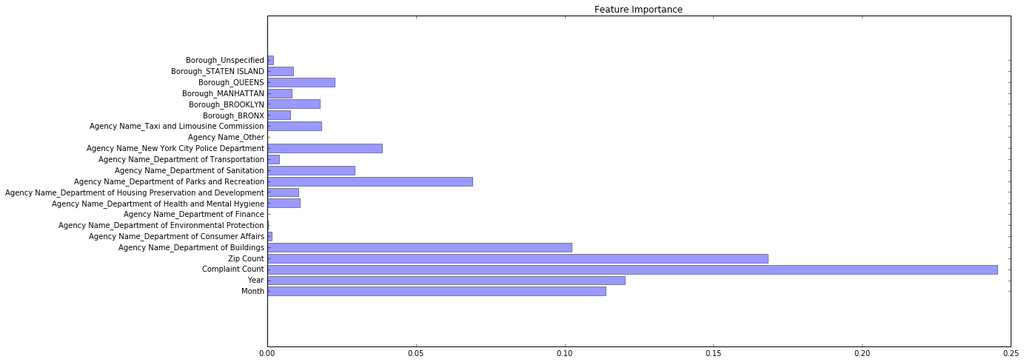

```python
y_pos = np.arange(len(features))

plt.barh(y_pos, dtree_model.feature_importances_, align='center', alpha=0.4)
plt.yticks(y_pos, features)
plt.title('Feature Importance')

plt.show()
```

# Feature Importance Changes Over Time

To observe the change in important features over time I created a function identical to the pipeline I used for the inital model that takes in a dataframe and the year and returns the evaluated RMSE as well as the most important features

```python
df3['Year'].value_counts()
```

```
2017    2366970
2016    2273752
2015    2181380
2014    2018497
2010    1890553
2013    1762321
2011    1733746
2012    1696563
2018     465157
Name: Year, dtype: int64
```

```python
def tree_features(df, year):
    df = df[df['Year'] == year]
    df.drop('Year', axis=1, inplace=True)

    features = [col for col in df.columns if col != 'Time Elapsed']

    X_train, X_test, y_train, y_test = model_selection.train_test_split(df[features].values,
                                                                    df["Time Elapsed"].values,
                                                                    test_size=0.3, random_state=42)

    dtree = tree.DecisionTreeRegressor()
    dtree_model = dtree.fit(X_train, y_train)
    predictions = dtree_model.predict(X_test)

    y_pos = np.arange(len(features))

    plt.barh(y_pos, dtree_model.feature_importances_, align='center', alpha=0.4)
    plt.yticks(y_pos, features)
    plt.title('Feature Importance')

    plt.show()

    print("RMSE Results", math.sqrt(metrics.mean_squared_error(y_test, predictions)))
```

## 2010

- In 2010 the type of complaint appears to be the most important with the zip code and month not far behind, the most important agency in predicting was the Department of Buildings

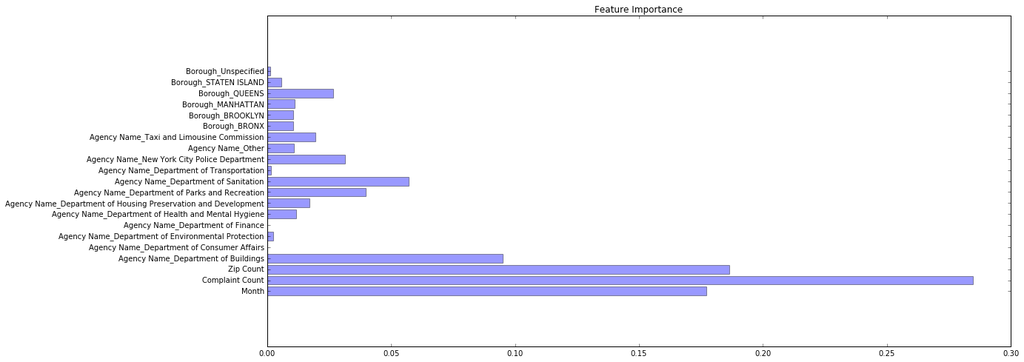

```
RMSE Results 25.253543322218967
```

```python
tree_features(df3, 2010)
```

## 2011

- In 2011 the complaint type, zip code, and month are all still most important however the Department of Buildings displays increased predictive performance

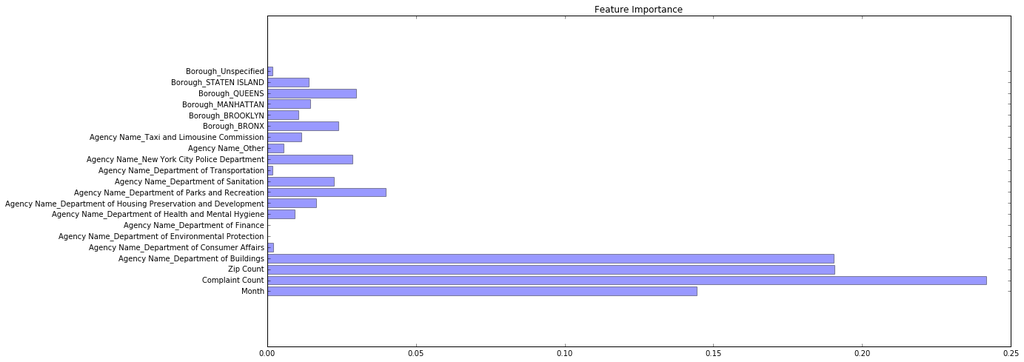

```
RMSE Results 24.53475003561235
```

```python
tree_features(df3, 2011)
```

## 2012

- The Department of Buildings in 2012 increases in feature importance again

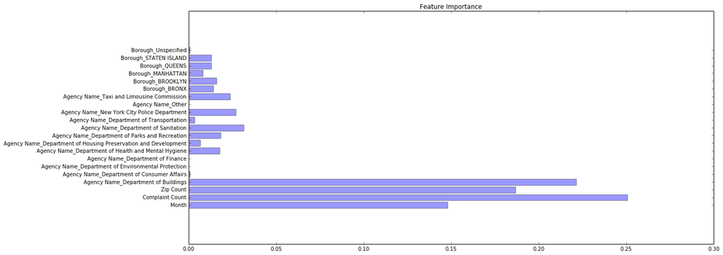

```
RMSE Results 24.91622010225243
```

```python
tree_features(df3, 2012)
```

## 2013

- In 2013 the Deparment of Buildings importance decreased as well, as a result the Department of Sanitation as well as the Department of Parks and Recreation are improved predictors

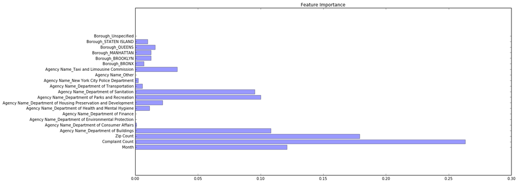

```
RMSE Results 25.922136545236185
```

```python
tree_features(df3, 2013)
```

## 2014

- In 2014 the Department of Buildings importance in prediction decreases again

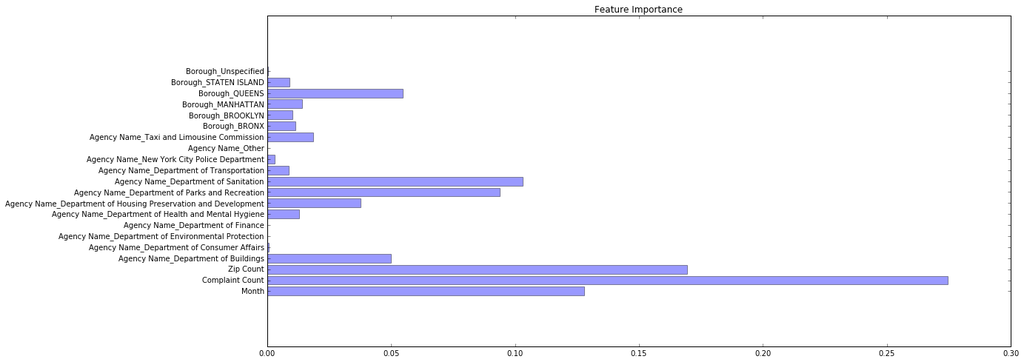

```
RMSE Results 27.424540243638134
```

```python
tree_features(df3, 2014)
```

## 2015

- In 2015 the Department of Buildings goes back to being the most important agency in the model

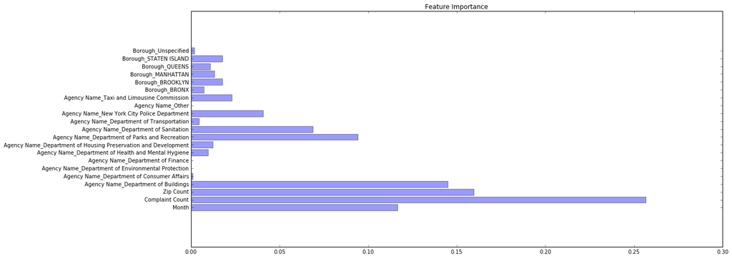

```
RMSE Results 26.06043011845888
```

```python
tree_features(df3, 2015)
```

## 2016

- In 2016 Sanitation along with Parks and Recreation have increased importance

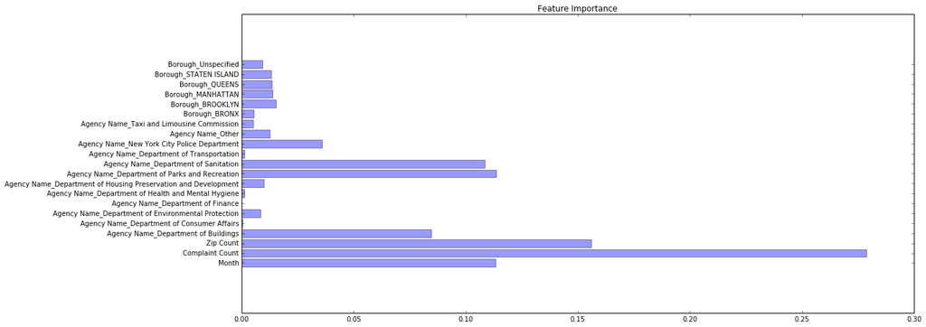

```
RMSE Results 22.950500975193517
```

```python
tree_features(df3, 2016)
```

## 2017

- In 2017 the Police Department is the most important agency in the model for the first time

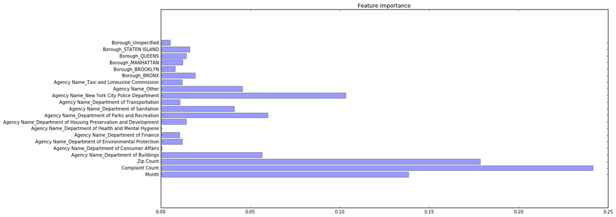

```
RMSE Results 17.621869410292305
```

```python
tree_features(df3, 2017)
```

# Conclusion

# Question: Are rat sightings more common in areas that have a higher density of restaurants with low inspection grades?

To answer this question we'll use an additional dataset showing NYC restaurant grades that can be found here: https://data.cityofnewyork.us/Health/DOHMH-New-York-City-Restaurant-Inspection-Results/43nn-pn8j

```python
obj = client.get_object(Bucket='interview-stuff', Key='restaurant_inspections.csv')
inspections =  pd.read_csv(io.BytesIO(obj['Body'].read()), dtype={'ZIPCODE':'str'})
```

```python
inspections.head(50)
```

|  | CAMIS | DBA | BORO | BUILDING | STREET | ZIPCODE | PHONE | CUISINE DESCRIPTION | INSPECTION DATE | ACTION | VIOLATION CODE | VIOLATION DESCRIPTION | CRITICAL FLAG | SCORE | GRADE | GRADE DATE | RECORD DATE | INSPECTION TYPE |
| --- | --- | --- | --- | --- | --- | --- | --- | --- | --- | --- | --- | --- | --- | --- | --- | --- | --- | --- |
| 0 | 50015075 | NEW YORK FRIED CHICKEN | BROOKLYN | 102 | SARATOGA AVE | 11233 | 7185522345 | Chicken | 04/28/2015 | Violations were cited in the following area(s). | 02G | Cold food item held above 41º F (smoked fish ... | Critical | 16.0 | B | 04/28/2015 | 03/01/2018 | Cycle Inspection / Re-inspection |
| 1 | 40364529 | BEN-BEST DELI & RESTAURANT | QUEENS | 9640 | QUEENS BOULEVARD | 11374 | 7188971700 | Jewish/Kosher | 03/24/2016 | Violations were cited in the following area(s). | 05B | Harmful, noxious gas or vapor detected. CO ~1 ... | Critical | 42.0 | C | 03/24/2016 | 03/01/2018 | Cycle Inspection / Re-inspection |
| 2 | 41580756 | ROTI ON THE RUN | BROOKLYN | 189 | NORWOOD AVENUE | 11208 | 7182354414 | Caribbean | 01/25/2018 | Violations were cited in the following area(s). | 10F | Non-food contact surface improperly constructe... | Not Critical | 9.0 | A | 01/25/2018 | 03/01/2018 | Cycle Inspection / Re-inspection |
| 3 | 50001255 | THE MILLING ROOM | MANHATTAN | 446 | COLUMBUS AVE | 10024 | 2125952624 | Italian | 07/30/2015 | Violations were cited in the following area(s). | 06E | Sanitized equipment or utensil, including in-u... | Critical | 28.0 | NaN | NaN | 03/01/2018 | Cycle Inspection / Initial Inspection |
| 4 | 50016437 | CHANG'S FAMILY RESTAURANT | QUEENS | 15428 | NORTHERN BLVD | 11354 | 7189392255 | Korean | 05/27/2015 | Violations were cited in the following area(s). | 06B | Tobacco use, eating, or drinking from open con... | Critical | 5.0 | A | 05/27/2015 | 03/01/2018 | Cycle Inspection / Re-inspection |
| 5 | 50000786 | DUNKIN' DONUTS | BROOKLYN | 873 | FLATBUSH AVENUE | 11226 | 7189400080 | Donuts | 12/10/2015 | Violations were cited in the following area(s). | 09C | Food contact surface not properly maintained. | Not Critical | 11.0 | A | 12/10/2015 | 03/01/2018 | Cycle Inspection / Initial Inspection |
| 6 | 41319308 | EUROPA CAFE | MANHATTAN | 2 | PARK AVENUE | 10016 | 2127255425 | Sandwiches/Salads/Mixed Buffet | 02/20/2015 | Violations were cited in the following area(s). | 10F | Non-food contact surface improperly constructe... | Not Critical | 7.0 | A | 02/20/2015 | 03/01/2018 | Cycle Inspection / Initial Inspection |
| 7 | 50018079 | ESPACE | MANHATTAN | 635 | W 42ND ST | 10036 | 2129677003 | American | 01/10/2018 | Violations were cited in the following area(s). | 04N | Filth flies or food/refuse/sewage-associated (... | Critical | 13.0 | A | 01/10/2018 | 03/01/2018 | Cycle Inspection / Initial Inspection |
| 8 | 50000768 | BUFFALO WILD WINGS, PEETS COFFEE & TEA, BENTO ... | QUEENS | NKA | JFK INTERNATIONAL AIRPORT | 11430 | 7187514769 | American | 05/14/2015 | Violations were cited in the following area(s). | 10F | Non-food contact surface improperly constructe... | Not Critical | 40.0 | NaN | NaN | 03/01/2018 | Cycle Inspection / Initial Inspection |
| 9 | 50008684 | LIZZMONADE | BROOKLYN | 1 | BROOKLYN BRIDGE PARK | 11201 | 9179308234 | Juice, Smoothies, Fruit Salads | 10/07/2015 | Violations were cited in the following area(s). | 04N | Filth flies or food/refuse/sewage-associated (... | Critical | 11.0 | A | 10/07/2015 | 03/01/2018 | Cycle Inspection / Initial Inspection |
| 10 | 50015315 | MY PIZZERIA | STATEN ISLAND | 755 | TARGEE ST | 10304 | 7187207777 | Pizza/Italian | 01/19/2017 | Violations were cited in the following area(s). | 08C | Pesticide use not in accordance with label or ... | Not Critical | 39.0 | C | 01/19/2017 | 03/01/2018 | Cycle Inspection / Re-inspection |
| 11 | 41720838 | ROTI MEDITERRANEAN GRILL | MANHATTAN | 100 | MAIDEN LANE | 10038 | 6464943359 | Mediterranean | 05/14/2014 | Violations were cited in the following area(s). | 02B | Hot food item not held at or above 140º F. | Critical | 11.0 | A | 05/14/2014 | 03/01/2018 | Cycle Inspection / Re-inspection |
| 12 | 40370507 | THE PLAYERS CLUB | MANHATTAN | 16 | GRAMERCY PARK SOUTH | 10003 | 2124756116 | American | 11/09/2016 | Violations were cited in the following area(s). | 04L | Evidence of mice or live mice present in facil... | Critical | 19.0 | NaN | NaN | 03/01/2018 | Cycle Inspection / Initial Inspection |
| 13 | 41089834 | MURRAY HILL DINER | MANHATTAN | 222 | LEXINGTON AVENUE | 10016 | 2126866667 | American | 03/21/2017 | Violations were cited in the following area(s). | 10F | Non-food contact surface improperly constructe... | Not Critical | 7.0 | A | 03/21/2017 | 03/01/2018 | Cycle Inspection / Initial Inspection |
| 14 | 50012832 | NATIONAL DINER | BRONX | 135 | WESTCHESTER SQ | 10461 | 7188241126 | American | 01/20/2015 | Violations were cited in the following area(s). | 15L | Smoke free workplace smoking policy inadequate... | Not Critical | NaN | NaN | NaN | 03/01/2018 | Smoke-Free Air Act / Re-inspection |
| 15 | 41675589 | AJI SUSHI HOUSE | QUEENS | 3606 | DITMARS BLVD | 11105 | 7187778885 | Japanese | 05/21/2015 | Violations were cited in the following area(s). | 08A | Facility not vermin proof. Harborage or condit... | Not Critical | 13.0 | A | 05/21/2015 | 03/01/2018 | Cycle Inspection / Re-inspection |
| 16 | 50001526 | EVERYDAY CHINESE RESTAURANT | BROOKLYN | 890 | WYCKOFF AVE | 11237 | 7183818899 | Chinese | 08/04/2014 | Violations were cited in the following area(s). | 04N | Filth flies or food/refuse/sewage-associated (... | Critical | 10.0 | A | 08/04/2014 | 03/01/2018 | Cycle Inspection / Re-inspection |
| 17 | 50008170 | SOUTH SHORE HOT BAGELS | STATEN ISLAND | 4882 | ARTHUR KILL RD | 10309 | 7182278600 | Delicatessen | 04/17/2014 | Violations were cited in the following area(s). | 06D | Food contact surface not properly washed, rins... | Critical | 36.0 | NaN | NaN | 03/01/2018 | Pre-permit (Operational) / Initial Inspection |
| 18 | 41236893 | NEPTUNE PIZZA | BROOKLYN | 3033 | CONEY ISLAND AVENUE | 11235 | 7189754472 | Pizza | 06/08/2015 | Violations were cited in the following area(s). | 09C | Food contact surface not properly maintained. | Not Critical | 29.0 | NaN | NaN | 03/01/2018 | Cycle Inspection / Initial Inspection |
| 19 | 50041083 | TENZAN 89 | MANHATTAN | 1714 | 2ND AVE | 10128 | 2123693600 | Japanese | 10/19/2016 | Violations were cited in the following area(s). | 06C | Food not protected from potential source of co... | Critical | 11.0 | A | 10/19/2016 | 03/01/2018 | Cycle Inspection / Initial Inspection |
| 20 | 41547596 | FUJI SUSHI BEDFORD | BROOKLYN | 1185 | BEDFORD AVENUE | 11216 | 3479851198 | Japanese | 10/01/2014 | Violations were cited in the following area(s). | 06E | Sanitized equipment or utensil, including in-u... | Critical | 55.0 | C | 10/01/2014 | 03/01/2018 | Cycle Inspection / Re-inspection |
| 21 | 41633054 | TASTE OF TACO/YUMMY CHINA | QUEENS | 6841 | MYRTLE AVE | 11385 | 7184564062 | Tex-Mex | 03/29/2017 | Establishment Closed by DOHMH. Violations wer... | 08C | Pesticide use not in accordance with label or ... | Not Critical | 52.0 | NaN | NaN | 03/01/2018 | Cycle Inspection / Initial Inspection |
| 22 | 40829164 | BUNGALOW BAR & RESTAURANT | QUEENS | 377 | BEACH 92 STREET | 11693 | 7189452100 | American | 08/11/2015 | Violations were cited in the following area(s). | 06C | Food not protected from potential source of co... | Critical | 28.0 | NaN | NaN | 03/01/2018 | Cycle Inspection / Initial Inspection |
| 23 | 40810784 | BARRAGE | MANHATTAN | 401 | WEST 47 STREET | 10036 | 2125869390 | American | 01/06/2015 | Violations were cited in the following area(s). | 15L | Smoke free workplace smoking policy inadequate... | Not Critical | NaN | NaN | NaN | 03/01/2018 | Smoke-Free Air Act / Re-inspection |
| 24 | 50044393 | RYUJIN RAMEN | BROOKLYN | 513 | GRAND ST | 11211 | 7187099888 | Japanese | 11/21/2016 | Violations were cited in the following area(s). | 08A | Facility not vermin proof. Harborage or condit... | Not Critical | 11.0 | A | 11/21/2016 | 03/01/2018 | Cycle Inspection / Re-inspection |
| 25 | 50033769 | NATIVIDAD RESTAURANT | QUEENS | 3766 | 103RD ST | 11368 | 3472040733 | Latin (Cuban, Dominican, Puerto Rican, South &... | 12/01/2015 | Violations were cited in the following area(s). | 06A | Personal cleanliness inadequate. Outer garment... | Critical | 8.0 | A | 12/01/2015 | 03/01/2018 | Cycle Inspection / Initial Inspection |
| 26 | 40786301 | EL RANCHITO DE DAISY | QUEENS | 4149 | 150 STREET | 11355 | 7186613307 | Latin (Cuban, Dominican, Puerto Rican, South &... | 02/06/2018 | No violations were recorded at the time of thi... | NaN | NaN | Not Applicable | NaN | NaN | NaN | 03/01/2018 | Administrative Miscellaneous / Initial Inspection |
| 27 | 41643816 | ROCCO'S BRICK OVEN PIZZERIA | QUEENS | 79-16 | 21 AVENUE | 11370 | 7187213535 | Pizza | 06/02/2016 | Violations were cited in the following area(s). | 10F | Non-food contact surface improperly constructe... | Not Critical | 13.0 | A | 06/02/2016 | 03/01/2018 | Cycle Inspection / Initial Inspection |
| 28 | 41611664 | SERVICE BAR 6 | QUEENS | 11000 | ROCKAWAY BOULEVARD | 11420 | 7182152828 | American | 12/07/2016 | Violations were cited in the following area(s). | 06D | Food contact surface not properly washed, rins... | Critical | 7.0 | A | 12/07/2016 | 03/01/2018 | Cycle Inspection / Initial Inspection |
| 29 | 41410071 | RIMINI PASTRY SHOPPE | BROOKLYN | 6822 | BAY PARKWAY | 11204 | 7182360644 | Bakery | 01/05/2015 | Violations were cited in the following area(s). | 06F | Wiping cloths soiled or not stored in sanitizi... | Critical | 14.0 | NaN | NaN | 03/01/2018 | Cycle Inspection / Initial Inspection |
| 30 | 41282827 | HAPPY GARDEN | QUEENS | 2926 | 30 AVENUE | 11102 | 7182741195 | Chinese | 11/16/2016 | Violations were cited in the following area(s). | 06C | Food not protected from potential source of co... | Critical | 19.0 | NaN | NaN | 03/01/2018 | Cycle Inspection / Initial Inspection |
| 31 | 50000045 | BURGER JOINT | MANHATTAN | 33 | W. 8TH ST | 10011 | 2124321400 | Hamburgers | 11/28/2016 | Violations were cited in the following area(s). | 06C | Food not protected from potential source of co... | Critical | 19.0 | B | 11/28/2016 | 03/01/2018 | Cycle Inspection / Re-inspection |
| 32 | 41627867 | DAVIDSTEA | MANHATTAN | 275 | BLEECKER STREET | 10014 | 2124148599 | Café/Coffee/Tea | 04/05/2016 | Violations were cited in the following area(s). | 10F | Non-food contact surface improperly constructe... | Not Critical | 21.0 | NaN | NaN | 03/01/2018 | Cycle Inspection / Initial Inspection |
| 33 | 50032822 | RED LION INN & SUITES | BROOKLYN | 279 | BUTLER ST | 11217 | 7188559600 | American | 08/25/2015 | Violations were cited in the following area(s). | 10H | Proper sanitization not provided for utensil w... | Not Critical | 26.0 | B | 08/25/2015 | 03/01/2018 | Pre-permit (Operational) / Re-inspection |
| 34 | 40390902 | SCOTTY'S DINER | MANHATTAN | 336 | LEXINGTON AVENUE | 10016 | 2129861520 | American | 03/02/2016 | Violations were cited in the following area(s). | 08C | Pesticide use not in accordance with label or ... | Not Critical | 14.0 | B | 03/02/2016 | 03/01/2018 | Cycle Inspection / Re-inspection |
| 35 | 50058366 | CAFE86 | MANHATTAN | 2350 | BROADWAY | 10024 | 2124964004 | Delicatessen | 02/06/2017 | Violations were cited in the following area(s). | 04N | Filth flies or food/refuse/sewage-associated (... | Critical | 22.0 | NaN | NaN | 03/01/2018 | Pre-permit (Operational) / Initial Inspection |
| 36 | 41701052 | GREEN CAFE | MANHATTAN | 1324 | LEXINGTON AVENUE | 10128 | 2122899100 | American | 05/18/2017 | Violations were cited in the following area(s). | 10F | Non-food contact surface improperly constructe... | Not Critical | 12.0 | A | 05/18/2017 | 03/01/2018 | Cycle Inspection / Initial Inspection |
| 37 | 41304245 | MANNA'S RESTAURANT | MANHATTAN | 54 | EAST 125 STREET | 10035 | 2123604975 | Soul Food | 04/06/2015 | Violations were cited in the following area(s). | 16B | The original nutritional fact labels and/or in... | Not Critical | NaN | NaN | NaN | 03/01/2018 | Trans Fat / Initial Inspection |
| 38 | 50018772 | LINDA ASIAN KITCHEN | BROOKLYN | 882 | DEKALB AVE | 11221 | 7185741686 | Chinese | 03/16/2015 | Violations were cited in the following area(s). | 06D | Food contact surface not properly washed, rins... | Critical | 12.0 | A | 03/16/2015 | 03/01/2018 | Pre-permit (Operational) / Re-inspection |
| 39 | 41414279 | JUST SALAD | MANHATTAN | 600 | 3 AVENUE | 10016 | 2126823832 | Salads | 02/11/2015 | Violations were cited in the following area(s). | 04L | Evidence of mice or live mice present in facil... | Critical | 10.0 | A | 02/11/2015 | 03/01/2018 | Cycle Inspection / Initial Inspection |
| 40 | 50038733 | HERO SHOP | BROOKLYN | 1211 | MCDONALD AVE | 11230 | 7183385472 | American | 09/15/2015 | Violations were cited in the following area(s). | 06C | Food not protected from potential source of co... | Critical | 37.0 | NaN | NaN | 03/01/2018 | Pre-permit (Operational) / Initial Inspection |
| 41 | 41109419 | THEATER ROW DINER | MANHATTAN | 424 | WEST 42 STREET | 10036 | 2124266000 | American | 09/14/2016 | Violations were cited in the following area(s). | 08A | Facility not vermin proof. Harborage or condit... | Not Critical | 20.0 | B | 09/14/2016 | 03/01/2018 | Cycle Inspection / Re-inspection |
| 42 | 40705931 | BLUE HILL RESTAURANT | MANHATTAN | 75 | WASHINGTON PLACE | 10011 | 2125391776 | American | 03/01/2016 | Violations were cited in the following area(s). | 05D | Hand washing facility not provided in or near ... | Critical | 13.0 | A | 03/01/2016 | 03/01/2018 | Cycle Inspection / Re-inspection |
| 43 | 41276395 | SAM'S PIZZA | BRONX | 232 | WEST 231 STREET | 10463 | 7185489070 | Pizza | 02/08/2017 | Violations were cited in the following area(s). | 02G | Cold food item held above 41º F (smoked fish ... | Critical | 11.0 | A | 02/08/2017 | 03/01/2018 | Cycle Inspection / Initial Inspection |
| 44 | 41182288 | MCDONALD'S | QUEENS | 9801 | METROPOLITAN AVENUE | 11375 | 7182637281 | Hamburgers | 04/18/2017 | Violations were cited in the following area(s). | 10I | Single service item reused, improperly stored,... | Not Critical | 12.0 | A | 04/18/2017 | 03/01/2018 | Cycle Inspection / Initial Inspection |
| 45 | 50047279 | CARBONE | MANHATTAN | 331 | W 38TH ST | 10018 | 2122902625 | Italian | 05/09/2017 | Violations were cited in the following area(s). | 04L | Evidence of mice or live mice present in facil... | Critical | 18.0 | B | 05/09/2017 | 03/01/2018 | Cycle Inspection / Re-inspection |
| 46 | 50033727 | PAPA JOHN'S | BROOKLYN | 1009 | BROADWAY | 11221 | 7184437272 | Pizza | 08/16/2016 | Establishment Closed by DOHMH. Violations wer... | 04N | Filth flies or food/refuse/sewage-associated (... | Critical | 37.0 | NaN | NaN | 03/01/2018 | Cycle Inspection / Initial Inspection |
| 47 | 41422787 | GREAT WALL | QUEENS | 25903 | HILLSIDE AVENUE | 11004 | 7189621111 | Chinese | 12/14/2016 | Violations were cited in the following area(s). | 10F | Non-food contact surface improperly constructe... | Not Critical | 9.0 | A | 12/14/2016 | 03/01/2018 | Cycle Inspection / Initial Inspection |
| 48 | 50009127 | BAGEL CAFE | BROOKLYN | 200 | CLINTON ST | 11201 | 7188586358 | Bagels/Pretzels | 01/12/2016 | Violations were cited in the following area(s). | 06C | Food not protected from potential source of co... | Critical | 12.0 | NaN | NaN | 03/01/2018 | Cycle Inspection / Initial Inspection |
| 49 | 50017825 | NEW JW GOLDEN BAKERY | BROOKLYN | 6017 | 4TH AVE | 11220 | 7187659199 | Bakery | 02/22/2017 | Violations were cited in the following area(s). | 08A | Facility not vermin proof. Harborage or condit... | Not Critical | 39.0 | NaN | NaN | 03/01/2018 | Cycle Inspection / Initial Inspection |

```python
len(inspections)
```

```
379674
```

```python
len(set(inspections['CAMIS']))
```

```
26484
```

# Approach

- To answer this question the I'll need to merge information from both dataframes and the only column that both dataframes share is the zipcode
- I can use pandas groupby function to groupby zipcode and then calculate the number of times a restaurant gets a grade with a C or Z

```python
inspections['GRADE'].value_counts()
```

```
A                 150439
B                  25109
C                   6384
Z                   3535
Not Yet Graded      2362
P                   1725
Name: GRADE, dtype: int64
```

```python
grade_counts = inspections.groupby(['ZIPCODE', 'GRADE']).size().unstack(fill_value=0)
grade_counts
```

| GRADE ZIPCODE | A | B | C | Not Yet Graded | P | Z |
| --- | --- | --- | --- | --- | --- | --- |
| 10001 | 2869 | 432 | 111 | 15 | 12 | 77 |
| 10002 | 2624 | 526 | 82 | 74 | 49 | 84 |
| 10003 | 4032 | 615 | 132 | 97 | 40 | 79 |
| 10004 | 883 | 105 | 22 | 5 | 6 | 4 |
| 10005 | 357 | 48 | 23 | 6 | 8 | 0 |
| 10006 | 261 | 41 | 25 | 5 | 2 | 8 |
| 10007 | 818 | 89 | 29 | 5 | 10 | 13 |
| 10009 | 1688 | 370 | 38 | 34 | 14 | 34 |
| 10010 | 1565 | 242 | 49 | 10 | 14 | 25 |
| 10011 | 2700 | 373 | 107 | 26 | 24 | 45 |
| 10012 | 2466 | 296 | 76 | 27 | 20 | 26 |
| 10013 | 2973 | 662 | 215 | 28 | 47 | 105 |
| 10014 | 2425 | 305 | 59 | 35 | 22 | 47 |
| 10016 | 2588 | 403 | 138 | 43 | 37 | 101 |
| 10017 | 2097 | 353 | 123 | 13 | 27 | 38 |
| 10018 | 2015 | 244 | 155 | 23 | 12 | 54 |
| 10019 | 4081 | 528 | 118 | 58 | 17 | 82 |
| 10020 | 276 | 4 | 9 | 0 | 2 | 7 |
| 10021 | 927 | 132 | 58 | 19 | 4 | 6 |
| 10022 | 2746 | 363 | 112 | 20 | 17 | 93 |
| 10023 | 1129 | 92 | 47 | 23 | 5 | 5 |
| 10024 | 1106 | 155 | 53 | 18 | 11 | 40 |
| 10025 | 1397 | 277 | 91 | 18 | 27 | 49 |
| 10026 | 473 | 159 | 11 | 3 | 6 | 18 |
| 10027 | 923 | 203 | 50 | 20 | 10 | 22 |
| 10028 | 1201 | 183 | 43 | 6 | 8 | 11 |
| 10029 | 1155 | 249 | 67 | 10 | 16 | 45 |
| 10030 | 245 | 33 | 6 | 20 | 5 | 3 |
| 10031 | 628 | 181 | 56 | 18 | 11 | 14 |
| 10032 | 679 | 177 | 42 | 12 | 12 | 2 |
| ... | ... | ... | ... | ... | ... | ... |
| 11385 | 1555 | 289 | 24 | 26 | 13 | 30 |
| 11411 | 135 | 18 | 2 | 8 | 3 | 1 |
| 11412 | 278 | 41 | 11 | 9 | 0 | 7 |
| 11413 | 281 | 48 | 3 | 4 | 5 | 0 |
| 11414 | 359 | 42 | 15 | 3 | 4 | 0 |
| 11415 | 213 | 45 | 10 | 4 | 0 | 0 |
| 11416 | 251 | 53 | 10 | 7 | 5 | 5 |
| 11417 | 427 | 114 | 23 | 10 | 0 | 9 |
| 11418 | 505 | 116 | 23 | 12 | 6 | 12 |
| 11419 | 545 | 95 | 25 | 10 | 16 | 19 |
| 11420 | 517 | 94 | 28 | 10 | 1 | 12 |
| 11421 | 478 | 94 | 27 | 6 | 4 | 17 |
| 11422 | 230 | 46 | 1 | 0 | 0 | 12 |
| 11423 | 193 | 20 | 8 | 0 | 2 | 5 |
| 11426 | 222 | 31 | 11 | 5 | 1 | 13 |
| 11427 | 147 | 20 | 7 | 0 | 4 | 0 |
| 11428 | 245 | 59 | 20 | 9 | 3 | 7 |
| 11429 | 154 | 18 | 0 | 0 | 1 | 6 |
| 11430 | 918 | 94 | 24 | 3 | 3 | 4 |
| 11432 | 1074 | 191 | 54 | 15 | 27 | 17 |
| 11433 | 160 | 26 | 6 | 4 | 2 | 4 |
| 11434 | 480 | 68 | 13 | 3 | 11 | 24 |
| 11435 | 750 | 119 | 23 | 6 | 5 | 22 |
| 11436 | 122 | 9 | 4 | 0 | 2 | 3 |
| 11451 | 11 | 0 | 7 | 0 | 0 | 0 |
| 11691 | 300 | 88 | 3 | 3 | 1 | 7 |
| 11692 | 61 | 6 | 0 | 0 | 0 | 0 |
| 11693 | 160 | 18 | 11 | 12 | 1 | 2 |
| 11694 | 296 | 11 | 0 | 0 | 5 | 3 |
| 11697 | 23 | 0 | 0 | 0 | 0 | 0 |

232 rows × 6 columns

```python
grade_counts.drop('Not Yet Graded', axis=1, inplace=True)
grade_counts['Total Ratings'] = grade_counts.sum(axis=1)
grade_counts['Bad Ratings'] = grade_counts['C'] + grade_counts['Z']
grade_counts['Bad Rating Percentage'] = grade_counts['Bad Ratings'] / grade_counts['Total Ratings']
grade_counts.reset_index(inplace=True)
```

```python
grade_counts.head()
```

| GRADE | ZIPCODE | A | B | C | P | Z | Total Ratings | Bad Ratings | Bad Rating Percentage |
| --- | --- | --- | --- | --- | --- | --- | --- | --- | --- |
| 0 | 10001 | 2869 | 432 | 111 | 12 | 77 | 3501 | 188 | 0.053699 |
| 1 | 10002 | 2624 | 526 | 82 | 49 | 84 | 3365 | 166 | 0.049331 |
| 2 | 10003 | 4032 | 615 | 132 | 40 | 79 | 4898 | 211 | 0.043079 |
| 3 | 10004 | 883 | 105 | 22 | 6 | 4 | 1020 | 26 | 0.025490 |
| 4 | 10005 | 357 | 48 | 23 | 8 | 0 | 436 | 23 | 0.052752 |

```python
merged = df2.merge(grade_counts, how='left', left_on='Incident Zip', right_on='ZIPCODE')
```

```python
merged.head()
```

|  | Unique Key | Created Date | Closed Date | Agency Name | Complaint Type | Borough | Incident Zip | Complaint Count | Zip Count | Time Elapsed | ... | Year | ZIPCODE | A | B | C | P | Z | Total Ratings | Bad Ratings | Bad Rating Percentage |
| --- | --- | --- | --- | --- | --- | --- | --- | --- | --- | --- | --- | --- | --- | --- | --- | --- | --- | --- | --- | --- | --- |
| 0 | 26435528 | 2013-10-04 08:32:00 | 2013-10-04 08:37:00 | Department of Environmental Protection | Water System | MANHATTAN | 10022 | 526614 | 67474 | 0.0 | ... | 2013 | 10022 | 2746.0 | 363.0 | 112.0 | 17.0 | 93.0 | 3331.0 | 205.0 | 0.061543 |
| 1 | 26435529 | 2013-10-04 12:21:00 | 2013-10-04 12:23:00 | Department of Environmental Protection | Water System | MANHATTAN | 10022 | 526614 | 67474 | 0.0 | ... | 2013 | 10022 | 2746.0 | 363.0 | 112.0 | 17.0 | 93.0 | 3331.0 | 205.0 | 0.061543 |
| 2 | 26435531 | 2013-10-04 12:22:00 | 2013-10-04 18:00:00 | Department of Environmental Protection | Water System | BROOKLYN | 11235 | 526614 | 149664 | 0.0 | ... | 2013 | 11235 | 1069.0 | 154.0 | 46.0 | 21.0 | 19.0 | 1309.0 | 65.0 | 0.049656 |
| 3 | 26435532 | 2013-10-04 12:28:00 | 2013-10-05 11:52:00 | Department of Environmental Protection | Asbestos | QUEENS | 11378 | 16315 | 77545 | 0.0 | ... | 2013 | 11378 | 525.0 | 50.0 | 22.0 | 10.0 | 0.0 | 607.0 | 22.0 | 0.036244 |
| 4 | 26435533 | 2013-10-04 08:45:00 | 2013-10-04 08:50:00 | Department of Environmental Protection | Water System | MANHATTAN | 10022 | 526614 | 67474 | 0.0 | ... | 2013 | 10022 | 2746.0 | 363.0 | 112.0 | 17.0 | 93.0 | 3331.0 | 205.0 | 0.061543 |

5 rows × 21 columns

```python
merged['Complaint Type'].value_counts()
```

```
Noise - Residential                  1393299
HEAT/HOT WATER                        879805
HEATING                               876529
Street Condition                      771647
Blocked Driveway                      669069
PLUMBING                              606623
Street Light Condition                579769
Illegal Parking                       577927
Water System                          519548
GENERAL CONSTRUCTION                  472978
Noise                                 365374
Traffic Signal Condition              361747
PAINT - PLASTER                       340763
UNSANITARY CONDITION                  313600
Noise - Street/Sidewalk               304134
Sewer                                 292977
Dirty Conditions                      282504
Noise - Commercial                    271155
PAINT/PLASTER                         259782
ELECTRIC                              257913
NONCONST                              246460
Sanitation Condition                  241279
General Construction/Plumbing         235290
Building/Use                          204603
DOF Literature Request                203444
Missed Collection (All Materials)     183969
Damaged Tree                          176456
Broken Muni Meter                     171134
Rodent                                157790
Derelict Vehicle                      155925
                                      ...
Animal Waste                               4
Employee Behavior                          4
Advocate - RPIE                            4
DOHMH Literature Request                   4
Mosquitoes                                 4
VACANT APARTMENT                           3
Misc. Comments                             3
Hazmat Storage/Use                         3
Graffiti or Vandalism                      3
Advocate-Business Tax                      3
Compliment                                 2
Baby Formula                               2
Illegal Pet - Sold/Kept                    2
Forms                                      2
Opinion for the Mayor                      2
Biking/Rollerblading Off Path              1
Asbestos/Garbage Nuisance                  1
Garbage or Litter                          1
LEAD                                       1
Unlicensed Dog                             1
Trapping Pigeon                            1
Advocate - Levy                            1
SG-99                                      1
Unspecified                                1
Animal unsanitary condition                1
Killing/Trapping Pigeon                    1
Advocate - Lien                            1
BBQ Outside Authorized Area                1
MOLD                                       1
CFC Recovery                               1
Name: Complaint Type, dtype: int64
```

```python
rats = merged[merged['Complaint Type'] == 'Rodent']
rats.head()
```

|  | Unique Key | Created Date | Closed Date | Agency Name | Complaint Type | Borough | Incident Zip | Complaint Count | Zip Count | Time Elapsed | ... | Year | ZIPCODE | A | B | C | P | Z | Total Ratings | Bad Ratings | Bad Rating Percentage |
| --- | --- | --- | --- | --- | --- | --- | --- | --- | --- | --- | --- | --- | --- | --- | --- | --- | --- | --- | --- | --- | --- |
| 4845 | 38365867 | 2018-02-01 | 2018-02-27 00:00:00 | Department of Health and Mental Hygiene | Rodent | BROOKLYN | 11238 | 212397 | 149261 | 26.0 | ... | 2018 | 11238 | 1329.0 | 189.0 | 48.0 | 10.0 | 3.0 | 1579.0 | 51.0 | 0.032299 |
| 6313 | 36838236 | 2017-07-31 | 2017-08-01 00:00:00 | Department of Health and Mental Hygiene | Rodent | BROOKLYN | 11211 | 212397 | 146734 | 1.0 | ... | 2017 | 11211 | 2184.0 | 248.0 | 68.0 | 14.0 | 78.0 | 2592.0 | 146.0 | 0.056327 |
| 14138 | 37746805 | 2017-11-20 | 2017-11-28 08:00:16 | Department of Health and Mental Hygiene | Rodent | QUEENS | 11385 | 212397 | 195258 | 8.0 | ... | 2017 | 11385 | 1555.0 | 289.0 | 24.0 | 13.0 | 30.0 | 1911.0 | 54.0 | 0.028257 |
| 22237 | 38373903 | 2018-02-02 | 2018-02-28 00:00:00 | Department of Health and Mental Hygiene | Rodent | MANHATTAN | 10030 | 212397 | 76082 | 26.0 | ... | 2018 | 10030 | 245.0 | 33.0 | 6.0 | 5.0 | 3.0 | 292.0 | 9.0 | 0.030822 |
| 45546 | 36841321 | 2017-08-01 | 2017-08-15 15:15:53 | Department of Health and Mental Hygiene | Rodent | BRONX | 10458 | 212397 | 226165 | 14.0 | ... | 2017 | 10458 | 1073.0 | 219.0 | 50.0 | 8.0 | 24.0 | 1374.0 | 74.0 | 0.053857 |

5 rows × 21 columns

```python
len(rats)
```

```
157790
```

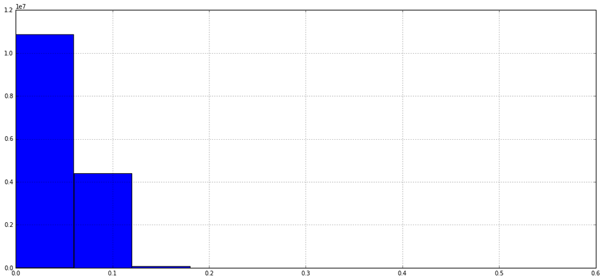

```python
merged['Bad Rating Percentage'].hist()
plt.show()
```

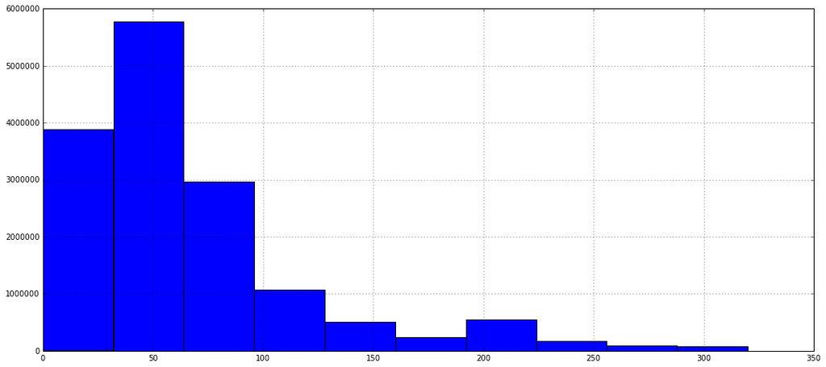

```python
merged['Bad Ratings'].hist()
plt.show()
```

```python
print('Average Number of Bad Inspection Ratings in Areas with Rodent Issues: {0}'.format(rats['Bad Rating Percentage'].mean()))
```

```
Average Number of Bad Inspection Ratings in Areas with Rodent Issues: 0.0532245896433475
```

```python
print('Average Number of Bad Inspection Ratings in Areas without Rodent Issues: {0}'.format(non_rats['Bad Rating Percentage'].mean()))
```

```
Average Number of Bad Inspection Ratings in Areas without Rodent Issues: 0.05341804629697087
```

```python
worse_ratings = merged[merged['Bad Rating Percentage'] > 0.05]
better_ratings = merged[merged['Bad Rating Percentage'] < 0.05]
```

```python
len(worse_ratings)
```

```
8016350
```

```python
len(better_ratings)
```

```
7287015
```

```python
len(worse_ratings[worse_ratings['Complaint Type'] == 'Rodent']) / len(worse_ratings)
```

```
0.0100096677415532
```

```python
len(better_ratings[better_ratings['Complaint Type'] == 'Rodent']) / len(better_ratings)
```

```
0.010496753471757641
```

# Conclusion

From this data there doesn't appear to be convincing evidence that rodent complaints are more likely to appear in zip codes with a higher percentage of restaurants with an inspection of grade of C or lower.

# Additional Questions

1. I would be interested to see what the demographics comparison of areas that have higher than average response times to service requests vs. areas with lower response times. This question would need demographic breakdown by zipcode within the NYC area including data on race, gender, age, etc. I would first create some comparative visualizations between above average and below average time elapsed with each particular feature. This could be a bit misleading due to the distribution of the time elapsed column. I would then use another non-linear model with and extract the most important features.
2. It would also be interesting to observe the funding of the departments that were particularly interesting and see if there are any fluctuations in time that correlate with their importance in prediction over time.

With the former having easier access to data - I will dive deeper into the demographics.

```python
obj = client.get_object(Bucket='interview-stuff', Key='Demographic_Statistics_By_Zip_Code.csv')
demo = pd.read_csv((io.BytesIO(obj['Body'].read())))
```

```python
demo
```

|  | JURISDICTION NAME | COUNT PARTICIPANTS | COUNT FEMALE | PERCENT FEMALE | COUNT MALE | PERCENT MALE | COUNT GENDER UNKNOWN | PERCENT GENDER UNKNOWN | COUNT GENDER TOTAL | PERCENT GENDER TOTAL | ... | COUNT CITIZEN STATUS TOTAL | PERCENT CITIZEN STATUS TOTAL | COUNT RECEIVES PUBLIC ASSISTANCE | PERCENT RECEIVES PUBLIC ASSISTANCE | COUNT NRECEIVES PUBLIC ASSISTANCE | PERCENT NRECEIVES PUBLIC ASSISTANCE | COUNT PUBLIC ASSISTANCE UNKNOWN | PERCENT PUBLIC ASSISTANCE UNKNOWN | COUNT PUBLIC ASSISTANCE TOTAL | PERCENT PUBLIC ASSISTANCE TOTAL |
| --- | --- | --- | --- | --- | --- | --- | --- | --- | --- | --- | --- | --- | --- | --- | --- | --- | --- | --- | --- | --- | --- |
| 0 | 10001 | 44 | 22 | 0.50 | 22 | 0.50 | 0 | 0 | 44 | 100 | ... | 44 | 100 | 20 | 0.45 | 24 | 0.55 | 0 | 0 | 44 | 100 |
| 1 | 10002 | 35 | 19 | 0.54 | 16 | 0.46 | 0 | 0 | 35 | 100 | ... | 35 | 100 | 2 | 0.06 | 33 | 0.94 | 0 | 0 | 35 | 100 |
| 2 | 10003 | 1 | 1 | 1.00 | 0 | 0.00 | 0 | 0 | 1 | 100 | ... | 1 | 100 | 0 | 0.00 | 1 | 1.00 | 0 | 0 | 1 | 100 |
| 3 | 10004 | 0 | 0 | 0.00 | 0 | 0.00 | 0 | 0 | 0 | 0 | ... | 0 | 0 | 0 | 0.00 | 0 | 0.00 | 0 | 0 | 0 | 0 |
| 4 | 10005 | 2 | 2 | 1.00 | 0 | 0.00 | 0 | 0 | 2 | 100 | ... | 2 | 100 | 0 | 0.00 | 2 | 1.00 | 0 | 0 | 2 | 100 |
| 5 | 10006 | 6 | 2 | 0.33 | 4 | 0.67 | 0 | 0 | 6 | 100 | ... | 6 | 100 | 0 | 0.00 | 6 | 1.00 | 0 | 0 | 6 | 100 |
| 6 | 10007 | 1 | 0 | 0.00 | 1 | 1.00 | 0 | 0 | 1 | 100 | ... | 1 | 100 | 1 | 1.00 | 0 | 0.00 | 0 | 0 | 1 | 100 |
| 7 | 10009 | 2 | 0 | 0.00 | 2 | 1.00 | 0 | 0 | 2 | 100 | ... | 2 | 100 | 0 | 0.00 | 2 | 1.00 | 0 | 0 | 2 | 100 |
| 8 | 10010 | 0 | 0 | 0.00 | 0 | 0.00 | 0 | 0 | 0 | 0 | ... | 0 | 0 | 0 | 0.00 | 0 | 0.00 | 0 | 0 | 0 | 0 |
| 9 | 10011 | 3 | 2 | 0.67 | 1 | 0.33 | 0 | 0 | 3 | 100 | ... | 3 | 100 | 0 | 0.00 | 3 | 1.00 | 0 | 0 | 3 | 100 |
| 10 | 10012 | 0 | 0 | 0.00 | 0 | 0.00 | 0 | 0 | 0 | 0 | ... | 0 | 0 | 0 | 0.00 | 0 | 0.00 | 0 | 0 | 0 | 0 |
| 11 | 10013 | 8 | 1 | 0.13 | 7 | 0.88 | 0 | 0 | 8 | 100 | ... | 8 | 100 | 1 | 0.13 | 7 | 0.88 | 0 | 0 | 8 | 100 |
| 12 | 10014 | 0 | 0 | 0.00 | 0 | 0.00 | 0 | 0 | 0 | 0 | ... | 0 | 0 | 0 | 0.00 | 0 | 0.00 | 0 | 0 | 0 | 0 |
| 13 | 10016 | 17 | 12 | 0.71 | 5 | 0.29 | 0 | 0 | 17 | 100 | ... | 17 | 100 | 9 | 0.53 | 8 | 0.47 | 0 | 0 | 17 | 100 |
| 14 | 10017 | 0 | 0 | 0.00 | 0 | 0.00 | 0 | 0 | 0 | 0 | ... | 0 | 0 | 0 | 0.00 | 0 | 0.00 | 0 | 0 | 0 | 0 |
| 15 | 10018 | 3 | 2 | 0.67 | 1 | 0.33 | 0 | 0 | 3 | 100 | ... | 3 | 100 | 0 | 0.00 | 3 | 1.00 | 0 | 0 | 3 | 100 |
| 16 | 10019 | 0 | 0 | 0.00 | 0 | 0.00 | 0 | 0 | 0 | 0 | ... | 0 | 0 | 0 | 0.00 | 0 | 0.00 | 0 | 0 | 0 | 0 |
| 17 | 10020 | 0 | 0 | 0.00 | 0 | 0.00 | 0 | 0 | 0 | 0 | ... | 0 | 0 | 0 | 0.00 | 0 | 0.00 | 0 | 0 | 0 | 0 |
| 18 | 10021 | 0 | 0 | 0.00 | 0 | 0.00 | 0 | 0 | 0 | 0 | ... | 0 | 0 | 0 | 0.00 | 0 | 0.00 | 0 | 0 | 0 | 0 |
| 19 | 10022 | 1 | 1 | 1.00 | 0 | 0.00 | 0 | 0 | 1 | 100 | ... | 1 | 100 | 0 | 0.00 | 1 | 1.00 | 0 | 0 | 1 | 100 |
| 20 | 10023 | 7 | 5 | 0.71 | 2 | 0.29 | 0 | 0 | 7 | 100 | ... | 7 | 100 | 5 | 0.71 | 2 | 0.29 | 0 | 0 | 7 | 100 |
| 21 | 10024 | 4 | 4 | 1.00 | 0 | 0.00 | 0 | 0 | 4 | 100 | ... | 4 | 100 | 1 | 0.25 | 3 | 0.75 | 0 | 0 | 4 | 100 |
| 22 | 10025 | 27 | 17 | 0.63 | 10 | 0.37 | 0 | 0 | 27 | 100 | ... | 27 | 100 | 8 | 0.30 | 19 | 0.70 | 0 | 0 | 27 | 100 |
| 23 | 10026 | 0 | 0 | 0.00 | 0 | 0.00 | 0 | 0 | 0 | 0 | ... | 0 | 0 | 0 | 0.00 | 0 | 0.00 | 0 | 0 | 0 | 0 |
| 24 | 10027 | 7 | 4 | 0.57 | 3 | 0.43 | 0 | 0 | 7 | 100 | ... | 7 | 100 | 1 | 0.14 | 6 | 0.86 | 0 | 0 | 7 | 100 |
| 25 | 10028 | 0 | 0 | 0.00 | 0 | 0.00 | 0 | 0 | 0 | 0 | ... | 0 | 0 | 0 | 0.00 | 0 | 0.00 | 0 | 0 | 0 | 0 |
| 26 | 10029 | 20 | 13 | 0.65 | 7 | 0.35 | 0 | 0 | 20 | 100 | ... | 20 | 100 | 8 | 0.40 | 12 | 0.60 | 0 | 0 | 20 | 100 |
| 27 | 10030 | 0 | 0 | 0.00 | 0 | 0.00 | 0 | 0 | 0 | 0 | ... | 0 | 0 | 0 | 0.00 | 0 | 0.00 | 0 | 0 | 0 | 0 |
| 28 | 10031 | 0 | 0 | 0.00 | 0 | 0.00 | 0 | 0 | 0 | 0 | ... | 0 | 0 | 0 | 0.00 | 0 | 0.00 | 0 | 0 | 0 | 0 |
| 29 | 10032 | 13 | 4 | 0.31 | 9 | 0.69 | 0 | 0 | 13 | 100 | ... | 13 | 100 | 5 | 0.38 | 8 | 0.62 | 0 | 0 | 13 | 100 |
| ... | ... | ... | ... | ... | ... | ... | ... | ... | ... | ... | ... | ... | ... | ... | ... | ... | ... | ... | ... | ... | ... |
| 206 | 11731 | 0 | 0 | 0.00 | 0 | 0.00 | 0 | 0 | 0 | 0 | ... | 0 | 0 | 0 | 0.00 | 0 | 0.00 | 0 | 0 | 0 | 0 |
| 207 | 11798 | 5 | 3 | 0.60 | 2 | 0.40 | 0 | 0 | 5 | 100 | ... | 5 | 100 | 0 | 0.00 | 5 | 1.00 | 0 | 0 | 5 | 100 |
| 208 | 11968 | 0 | 0 | 0.00 | 0 | 0.00 | 0 | 0 | 0 | 0 | ... | 0 | 0 | 0 | 0.00 | 0 | 0.00 | 0 | 0 | 0 | 0 |
| 209 | 12423 | 21 | 1 | 0.05 | 20 | 0.95 | 0 | 0 | 21 | 100 | ... | 21 | 100 | 5 | 0.24 | 16 | 0.76 | 0 | 0 | 21 | 100 |
| 210 | 12428 | 124 | 74 | 0.60 | 50 | 0.40 | 0 | 0 | 124 | 100 | ... | 124 | 100 | 71 | 0.57 | 53 | 0.43 | 0 | 0 | 124 | 100 |
| 211 | 12435 | 55 | 5 | 0.09 | 50 | 0.91 | 0 | 0 | 55 | 100 | ... | 55 | 100 | 19 | 0.35 | 36 | 0.65 | 0 | 0 | 55 | 100 |
| 212 | 12458 | 0 | 0 | 0.00 | 0 | 0.00 | 0 | 0 | 0 | 0 | ... | 0 | 0 | 0 | 0.00 | 0 | 0.00 | 0 | 0 | 0 | 0 |
| 213 | 12466 | 44 | 44 | 1.00 | 0 | 0.00 | 0 | 0 | 44 | 100 | ... | 44 | 100 | 35 | 0.80 | 9 | 0.20 | 0 | 0 | 44 | 100 |
| 214 | 12473 | 0 | 0 | 0.00 | 0 | 0.00 | 0 | 0 | 0 | 0 | ... | 0 | 0 | 0 | 0.00 | 0 | 0.00 | 0 | 0 | 0 | 0 |
| 215 | 12528 | 52 | 2 | 0.04 | 50 | 0.96 | 0 | 0 | 52 | 100 | ... | 52 | 100 | 21 | 0.40 | 31 | 0.60 | 0 | 0 | 52 | 100 |
| 216 | 12701 | 87 | 49 | 0.56 | 38 | 0.44 | 0 | 0 | 87 | 100 | ... | 87 | 100 | 18 | 0.21 | 69 | 0.79 | 0 | 0 | 87 | 100 |
| 217 | 12733 | 13 | 6 | 0.46 | 7 | 0.54 | 0 | 0 | 13 | 100 | ... | 13 | 100 | 2 | 0.15 | 11 | 0.85 | 0 | 0 | 13 | 100 |
| 218 | 12734 | 252 | 170 | 0.67 | 82 | 0.33 | 0 | 0 | 252 | 100 | ... | 252 | 100 | 61 | 0.24 | 191 | 0.76 | 0 | 0 | 252 | 100 |
| 219 | 12737 | 35 | 34 | 0.97 | 1 | 0.03 | 0 | 0 | 35 | 100 | ... | 35 | 100 | 20 | 0.57 | 15 | 0.43 | 0 | 0 | 35 | 100 |
| 220 | 12750 | 37 | 36 | 0.97 | 1 | 0.03 | 0 | 0 | 37 | 100 | ... | 37 | 100 | 21 | 0.57 | 16 | 0.43 | 0 | 0 | 37 | 100 |
| 221 | 12751 | 7 | 2 | 0.29 | 5 | 0.71 | 0 | 0 | 7 | 100 | ... | 7 | 100 | 2 | 0.29 | 5 | 0.71 | 0 | 0 | 7 | 100 |
| 222 | 12754 | 134 | 64 | 0.48 | 70 | 0.52 | 0 | 0 | 134 | 100 | ... | 134 | 100 | 27 | 0.20 | 107 | 0.80 | 0 | 0 | 134 | 100 |
| 223 | 12758 | 82 | 50 | 0.61 | 32 | 0.39 | 0 | 0 | 82 | 100 | ... | 82 | 100 | 24 | 0.29 | 58 | 0.71 | 0 | 0 | 82 | 100 |
| 224 | 12759 | 11 | 0 | 0.00 | 11 | 1.00 | 0 | 0 | 11 | 100 | ... | 11 | 100 | 8 | 0.73 | 3 | 0.27 | 0 | 0 | 11 | 100 |
| 225 | 12763 | 11 | 11 | 1.00 | 0 | 0.00 | 0 | 0 | 11 | 100 | ... | 11 | 100 | 8 | 0.73 | 3 | 0.27 | 0 | 0 | 11 | 100 |
| 226 | 12764 | 64 | 61 | 0.95 | 3 | 0.05 | 0 | 0 | 64 | 100 | ... | 64 | 100 | 5 | 0.08 | 59 | 0.92 | 0 | 0 | 64 | 100 |
| 227 | 12768 | 63 | 1 | 0.02 | 62 | 0.98 | 0 | 0 | 63 | 100 | ... | 63 | 100 | 23 | 0.37 | 40 | 0.63 | 0 | 0 | 63 | 100 |
| 228 | 12779 | 242 | 183 | 0.76 | 59 | 0.24 | 0 | 0 | 242 | 100 | ... | 242 | 100 | 155 | 0.64 | 87 | 0.36 | 0 | 0 | 242 | 100 |
| 229 | 12783 | 201 | 66 | 0.33 | 135 | 0.67 | 0 | 0 | 201 | 100 | ... | 201 | 100 | 77 | 0.38 | 124 | 0.62 | 0 | 0 | 201 | 100 |
| 230 | 12786 | 4 | 3 | 0.75 | 1 | 0.25 | 0 | 0 | 4 | 100 | ... | 4 | 100 | 1 | 0.25 | 3 | 0.75 | 0 | 0 | 4 | 100 |
| 231 | 12788 | 83 | 39 | 0.47 | 44 | 0.53 | 0 | 0 | 83 | 100 | ... | 83 | 100 | 35 | 0.42 | 48 | 0.58 | 0 | 0 | 83 | 100 |
| 232 | 12789 | 272 | 115 | 0.42 | 157 | 0.58 | 0 | 0 | 272 | 100 | ... | 272 | 100 | 70 | 0.26 | 202 | 0.74 | 0 | 0 | 272 | 100 |
| 233 | 13731 | 17 | 2 | 0.12 | 15 | 0.88 | 0 | 0 | 17 | 100 | ... | 17 | 100 | 7 | 0.41 | 10 | 0.59 | 0 | 0 | 17 | 100 |
| 234 | 16091 | 0 | 0 | 0.00 | 0 | 0.00 | 0 | 0 | 0 | 0 | ... | 0 | 0 | 0 | 0.00 | 0 | 0.00 | 0 | 0 | 0 | 0 |
| 235 | 20459 | 0 | 0 | 0.00 | 0 | 0.00 | 0 | 0 | 0 | 0 | ... | 0 | 0 | 0 | 0.00 | 0 | 0.00 | 0 | 0 | 0 | 0 |

236 rows × 46 columns

```python
demo = demo[demo['COUNT PARTICIPANTS'] >= 50]
len(demo)
```

```
27
```

```python
columns = [col for col in demo.columns if 'PERCENT' in col or col == 'JURISDICTION NAME']
demo = demo[columns]
demo
```

|  | JURISDICTION NAME | PERCENT FEMALE | PERCENT MALE | PERCENT GENDER UNKNOWN | PERCENT GENDER TOTAL | PERCENT PACIFIC ISLANDER | PERCENT HISPANIC LATINO | PERCENT AMERICAN INDIAN | PERCENT ASIAN NON HISPANIC | PERCENT WHITE NON HISPANIC | ... | PERCENT ETHNICITY TOTAL | PERCENT PERMANENT RESIDENT ALIEN | PERCENT US CITIZEN | PERCENT OTHER CITIZEN STATUS | PERCENT CITIZEN STATUS UNKNOWN | PERCENT CITIZEN STATUS TOTAL | PERCENT RECEIVES PUBLIC ASSISTANCE | PERCENT NRECEIVES PUBLIC ASSISTANCE | PERCENT PUBLIC ASSISTANCE UNKNOWN | PERCENT PUBLIC ASSISTANCE TOTAL |
| --- | --- | --- | --- | --- | --- | --- | --- | --- | --- | --- | --- | --- | --- | --- | --- | --- | --- | --- | --- | --- | --- |
| 65 | 10458 | 0.48 | 0.52 | 0 | 100 | 0.00 | 0.46 | 0.00 | 0.00 | 0.02 | ... | 100 | 0.06 | 0.92 | 0.02 | 0 | 100 | 0.37 | 0.63 | 0 | 100 |
| 70 | 10463 | 0.56 | 0.44 | 0 | 100 | 0.00 | 0.61 | 0.00 | 0.00 | 0.03 | ... | 100 | 0.05 | 0.92 | 0.03 | 0 | 100 | 0.34 | 0.66 | 0 | 100 |
| 73 | 10466 | 0.60 | 0.40 | 0 | 100 | 0.02 | 0.22 | 0.00 | 0.00 | 0.00 | ... | 100 | 0.05 | 0.95 | 0.00 | 0 | 100 | 0.26 | 0.74 | 0 | 100 |
| 74 | 10467 | 0.61 | 0.39 | 0 | 100 | 0.00 | 0.48 | 0.01 | 0.04 | 0.01 | ... | 100 | 0.09 | 0.89 | 0.02 | 0 | 100 | 0.31 | 0.69 | 0 | 100 |
| 75 | 10468 | 0.57 | 0.43 | 0 | 100 | 0.00 | 0.43 | 0.00 | 0.04 | 0.00 | ... | 100 | 0.02 | 0.98 | 0.00 | 0 | 100 | 0.28 | 0.72 | 0 | 100 |
| 119 | 11218 | 0.87 | 0.13 | 0 | 100 | 0.00 | 0.01 | 0.00 | 0.03 | 0.86 | ... | 100 | 0.07 | 0.92 | 0.01 | 0 | 100 | 0.46 | 0.54 | 0 | 100 |
| 120 | 11219 | 0.85 | 0.15 | 0 | 100 | 0.00 | 0.00 | 0.00 | 0.00 | 0.96 | ... | 99 | 0.01 | 0.99 | 0.00 | 0 | 100 | 0.52 | 0.48 | 0 | 100 |
| 124 | 11223 | 0.49 | 0.51 | 0 | 100 | 0.00 | 0.01 | 0.00 | 0.06 | 0.87 | ... | 100 | 0.06 | 0.94 | 0.01 | 0 | 100 | 0.18 | 0.82 | 0 | 100 |
| 125 | 11224 | 0.57 | 0.43 | 0 | 100 | 0.00 | 0.15 | 0.00 | 0.08 | 0.04 | ... | 100 | 0.06 | 0.92 | 0.01 | 0 | 99 | 0.30 | 0.70 | 0 | 100 |
| 126 | 11225 | 1.00 | 0.00 | 0 | 100 | 0.00 | 0.00 | 0.00 | 0.00 | 1.00 | ... | 100 | 0.00 | 1.00 | 0.00 | 0 | 100 | 0.42 | 0.58 | 0 | 100 |
| 129 | 11229 | 0.62 | 0.38 | 0 | 100 | 0.00 | 0.04 | 0.00 | 0.10 | 0.75 | ... | 100 | 0.06 | 0.94 | 0.00 | 0 | 100 | 0.10 | 0.90 | 0 | 100 |
| 130 | 11230 | 0.78 | 0.22 | 0 | 100 | 0.00 | 0.00 | 0.00 | 0.03 | 0.87 | ... | 100 | 0.01 | 0.99 | 0.00 | 0 | 100 | 0.17 | 0.83 | 0 | 100 |
| 134 | 11234 | 0.49 | 0.51 | 0 | 100 | 0.00 | 0.14 | 0.00 | 0.00 | 0.63 | ... | 100 | 0.02 | 0.98 | 0.00 | 0 | 100 | 0.03 | 0.97 | 0 | 100 |
| 135 | 11235 | 0.34 | 0.66 | 0 | 100 | 0.00 | 0.14 | 0.00 | 0.08 | 0.72 | ... | 100 | 0.02 | 0.96 | 0.02 | 0 | 100 | 0.08 | 0.92 | 0 | 100 |
| 210 | 12428 | 0.60 | 0.40 | 0 | 100 | 0.02 | 0.01 | 0.00 | 0.00 | 0.94 | ... | 100 | 0.00 | 1.00 | 0.00 | 0 | 100 | 0.57 | 0.43 | 0 | 100 |
| 211 | 12435 | 0.09 | 0.91 | 0 | 100 | 0.00 | 0.00 | 0.00 | 0.00 | 0.91 | ... | 100 | 0.00 | 1.00 | 0.00 | 0 | 100 | 0.35 | 0.65 | 0 | 100 |
| 215 | 12528 | 0.04 | 0.96 | 0 | 100 | 0.00 | 0.00 | 0.00 | 0.00 | 0.88 | ... | 100 | 0.02 | 0.98 | 0.00 | 0 | 100 | 0.40 | 0.60 | 0 | 100 |
| 216 | 12701 | 0.56 | 0.44 | 0 | 100 | 0.00 | 0.00 | 0.00 | 0.00 | 0.95 | ... | 99 | 0.00 | 1.00 | 0.00 | 0 | 100 | 0.21 | 0.79 | 0 | 100 |
| 218 | 12734 | 0.67 | 0.33 | 0 | 100 | 0.00 | 0.00 | 0.00 | 0.00 | 0.96 | ... | 100 | 0.00 | 1.00 | 0.00 | 0 | 100 | 0.24 | 0.76 | 0 | 100 |
| 222 | 12754 | 0.48 | 0.52 | 0 | 100 | 0.01 | 0.00 | 0.00 | 0.00 | 0.95 | ... | 100 | 0.01 | 0.99 | 0.00 | 0 | 100 | 0.20 | 0.80 | 0 | 100 |
| 223 | 12758 | 0.61 | 0.39 | 0 | 100 | 0.00 | 0.00 | 0.00 | 0.00 | 0.93 | ... | 100 | 0.00 | 1.00 | 0.00 | 0 | 100 | 0.29 | 0.71 | 0 | 100 |
| 226 | 12764 | 0.95 | 0.05 | 0 | 100 | 0.00 | 0.00 | 0.00 | 0.00 | 0.97 | ... | 100 | 0.00 | 1.00 | 0.00 | 0 | 100 | 0.08 | 0.92 | 0 | 100 |
| 227 | 12768 | 0.02 | 0.98 | 0 | 100 | 0.00 | 0.00 | 0.00 | 0.00 | 0.97 | ... | 100 | 0.00 | 1.00 | 0.00 | 0 | 100 | 0.37 | 0.63 | 0 | 100 |
| 228 | 12779 | 0.76 | 0.24 | 0 | 100 | 0.00 | 0.00 | 0.00 | 0.00 | 0.99 | ... | 100 | 0.00 | 1.00 | 0.00 | 0 | 100 | 0.64 | 0.36 | 0 | 100 |
| 229 | 12783 | 0.33 | 0.67 | 0 | 100 | 0.00 | 0.00 | 0.01 | 0.00 | 0.97 | ... | 99 | 0.02 | 0.98 | 0.00 | 0 | 100 | 0.38 | 0.62 | 0 | 100 |
| 231 | 12788 | 0.47 | 0.53 | 0 | 100 | 0.00 | 0.00 | 0.00 | 0.00 | 0.98 | ... | 100 | 0.00 | 1.00 | 0.00 | 0 | 100 | 0.42 | 0.58 | 0 | 100 |
| 232 | 12789 | 0.42 | 0.58 | 0 | 100 | 0.00 | 0.00 | 0.00 | 0.00 | 0.96 | ... | 99 | 0.00 | 1.00 | 0.00 | 0 | 100 | 0.26 | 0.74 | 0 | 100 |

27 rows × 23 columns

# Conclusion

There isn't enough data in this dataset for us to gain much analytical insight - however the information here is what I am looking for to see if it has an effect on the time elapsed from complaint creation date.